# Module 21

#### Contrast SVE:

Signed variance explained (SVE) provides an indication of how similar a set of fold changes are to a gene module’s weight vector. An SVE value of 0.3, for example, indicates that 30% of the variance explained by the entire module set is accounted for by the module in question. Shown here are the SVE values for this module across a compendium of fold changes (contrasts). Extreme SVE values (e.g., > 0.05) indicate that those contrasts specifically induce (orange dots) or specifically repress (blue dots) this module. Examining the experimental conditions being compared in such contrasts (see tables below the figure) may provide insight into the gene module’s function.

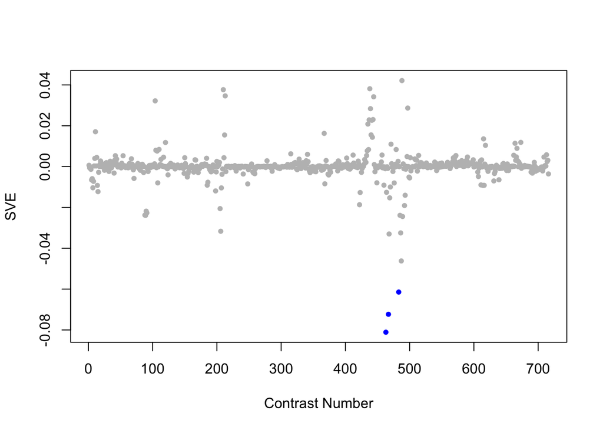

Positive SVE Contrasts:

|  | Contrast.Num | SVE | GEO.GSE | Cond.1 | Cond.2 | Mutation |
| --- | --- | --- | --- | --- | --- | --- |
| GSE23528B.s1t2.vs.s1t1 | 488 | 0.04 | GSE23528 | Adult at T30 in CC, time-series experiment 3 | Adult at T26 in CC, time-series experiment 3 |  |
| GSE27677B.s1t6.vs.s1t1 | 438 | 0.04 | GSE27677 | N2, Fast 18 h, rep 1 | N2, Fed 0 h, rep 1 |  |
| GSE42689.s3t1.vs.s1t1 | 210 | 0.04 | GSE42689 | mlk-1 fasted 1 | mek-1 fasted 1 |  |
| GSE42689.s4t1.vs.s2t1 | 213 | 0.03 | GSE42689 | mlk-1 fed 1 | mek-1 fed 1 |  |
| GSE27677B.s1t4.vs.s1t1 | 444 | 0.03 | GSE27677 | N2, Fast 9 h, rep 1 | N2, Fed 0 h, rep 1 |  |

Negative SVE Contrasts:

|  | Contrast.Num | SVE | GEO.GSE | Cond.1 | Cond.2 | Mutation |
| --- | --- | --- | --- | --- | --- | --- |
| GSE23528A.s1t4.vs.s0t4 | 463 | -0.08 | GSE23528 | Adult at T14 in LD, time-series experiment 3 | Adult at T14, non-entrained control time-series experiment 4 |  |
| GSE23528A.s1t1.vs.s0t1 | 467 | -0.07 | GSE23528 | Adult at T2 in LD, time-series experiment 3 | Adult at T2, non-entrained control time-series experiment 4 |  |
| GSE23528A.s0t3.vs.s0t1 | 483 | -0.06 | GSE23528 | Adult at T10, non-entrained control time-series experiment 4 | Adult at T2, non-entrained control time-series experiment 4 |  |
| GSE23528A.s0t2.vs.s0t1 | 487 | -0.05 | GSE23528 | Adult at T6, non-entrained control time-series experiment 4 | Adult at T2, non-entrained control time-series experiment 4 |  |
| GSE23528A.s2t1.vs.s0t1 | 468 | -0.03 | GSE23528 | Adult at T2 in WC, time-series experiment 1 | Adult at T2, non-entrained control time-series experiment 4 |  |

$~$

#### Contrast SVE, Up-Regulated Genes Only:

Calculating SVE for up-regulated and down-regulated genes separately may be more informative in many cases than projecting the up- and down- gene sets together. This is due to the fact that the weight distribution of many modules is highly skewed, indicating that only one of the hemi-modules may be biologically meaningful (i.e., a set of genes are strongly correlated by only a few genes (or none) are strongly anti-correlated to that set.)

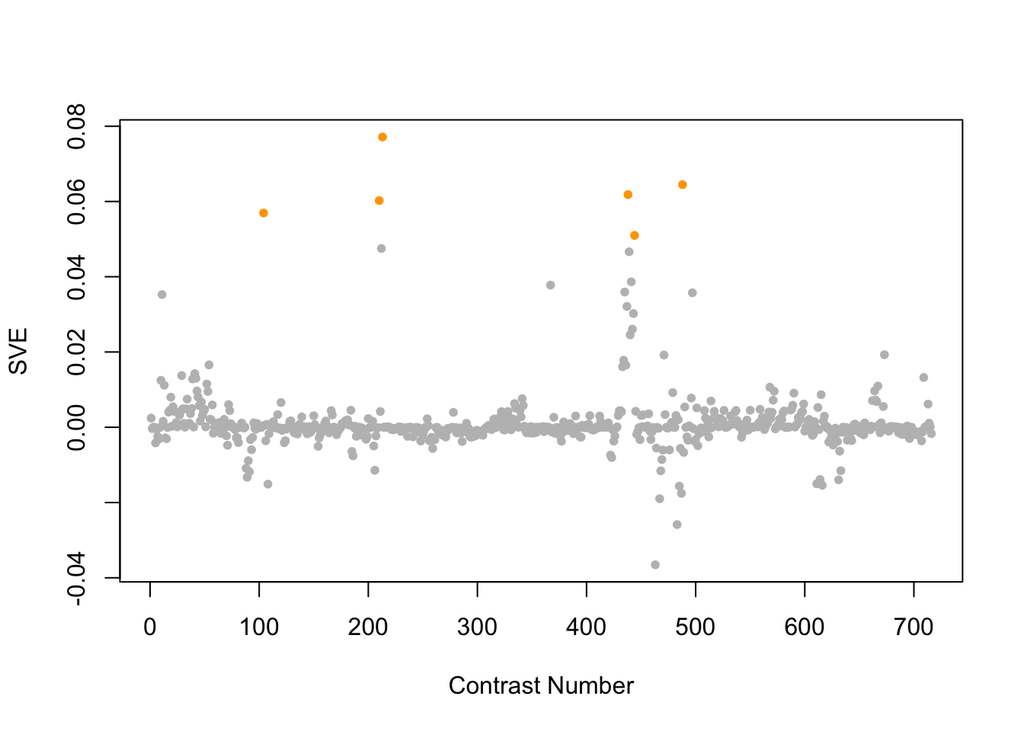

Positive SVE Contrasts:

|  | Contrast.Num | SVE | GEO.GSE | Cond.1 | Cond.2 | Mutation |
| --- | --- | --- | --- | --- | --- | --- |
| GSE42689.s4t1.vs.s2t1 | 213 | 0.08 | GSE42689 | mlk-1 fed 1 | mek-1 fed 1 |  |
| GSE23528B.s1t2.vs.s1t1 | 488 | 0.06 | GSE23528 | Adult at T30 in CC, time-series experiment 3 | Adult at T26 in CC, time-series experiment 3 |  |
| GSE27677B.s1t6.vs.s1t1 | 438 | 0.06 | GSE27677 | N2, Fast 18 h, rep 1 | N2, Fed 0 h, rep 1 |  |
| GSE42689.s3t1.vs.s1t1 | 210 | 0.06 | GSE42689 | mlk-1 fasted 1 | mek-1 fasted 1 |  |
| GSE57664.s1t1.vs.s0t1 | 104 | 0.06 | GSE57664 | TYR treated rep1 | control rep1 |  |
| GSE27677B.s1t4.vs.s1t1 | 444 | 0.05 | GSE27677 | N2, Fast 9 h, rep 1 | N2, Fed 0 h, rep 1 |  |

Negative SVE Contrasts:

|  | Contrast.Num | SVE | GEO.GSE | Cond.1 | Cond.2 | Mutation |
| --- | --- | --- | --- | --- | --- | --- |
| GSE23528A.s1t4.vs.s0t4 | 463 | -0.04 | GSE23528 | Adult at T14 in LD, time-series experiment 3 | Adult at T14, non-entrained control time-series experiment 4 |  |
| GSE23528A.s0t3.vs.s0t1 | 483 | -0.03 | GSE23528 | Adult at T10, non-entrained control time-series experiment 4 | Adult at T2, non-entrained control time-series experiment 4 |  |
| GSE23528A.s1t1.vs.s0t1 | 467 | -0.02 | GSE23528 | Adult at T2 in LD, time-series experiment 3 | Adult at T2, non-entrained control time-series experiment 4 |  |
| GSE23528A.s0t2.vs.s0t1 | 487 | -0.02 | GSE23528 | Adult at T6, non-entrained control time-series experiment 4 | Adult at T2, non-entrained control time-series experiment 4 |  |
| GSE23528A.s0t5.vs.s0t1 | 485 | -0.02 | GSE23528 | Adult at T18, non-entrained control time-series experiment 4 | Adult at T2, non-entrained control time-series experiment 4 |  |

$~$

#### Contrast SVE, Down-Regulated Genes Only:

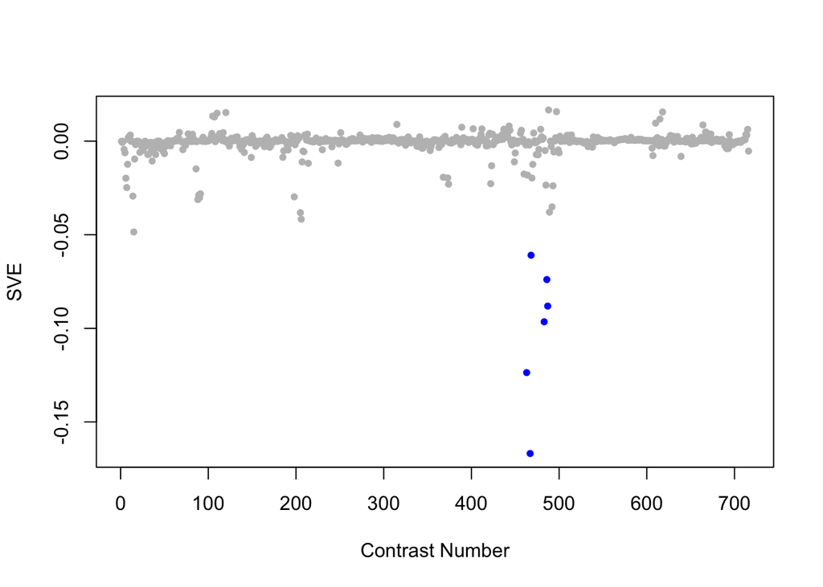

Positive SVE Contrasts:

|  | Contrast.Num | SVE | GEO.GSE | Cond.1 | Cond.2 | Mutation |
| --- | --- | --- | --- | --- | --- | --- |
| GSE23528B.s1t2.vs.s1t1 | 488 | 0.02 | GSE23528 | Adult at T30 in CC, time-series experiment 3 | Adult at T26 in CC, time-series experiment 3 |  |
| GSE23528C.s1t6.vs.s1t1 | 497 | 0.02 | GSE23528 | Adult at T46 in DD, time-series experiment 2 | Adult at T26 in DD, time-series experiment 2 |  |
| GSE21591.s1t1.vs.s2t1 | 618 | 0.02 | GSE21591 | N2_aFLAG_1 | Input_1 |  |
| GSE54024.s3t1.vs.s4t1 | 120 | 0.02 | GSE54024 | nuo-6(qm200) young adults, biological rep 1 | isp-1(qm150) young adults, biological rep 1 |  |
| GSE54513.s4t1.vs.s3t1 | 110 | 0.01 | GSE54513 | spe-9 OMA-1 IP rep1 | spe-9 input rep1 |  |

Negative SVE Contrasts:

|  | Contrast.Num | SVE | GEO.GSE | Cond.1 | Cond.2 | Mutation |
| --- | --- | --- | --- | --- | --- | --- |
| GSE23528A.s1t1.vs.s0t1 | 467 | -0.17 | GSE23528 | Adult at T2 in LD, time-series experiment 3 | Adult at T2, non-entrained control time-series experiment 4 |  |
| GSE23528A.s1t4.vs.s0t4 | 463 | -0.12 | GSE23528 | Adult at T14 in LD, time-series experiment 3 | Adult at T14, non-entrained control time-series experiment 4 |  |
| GSE23528A.s0t3.vs.s0t1 | 483 | -0.10 | GSE23528 | Adult at T10, non-entrained control time-series experiment 4 | Adult at T2, non-entrained control time-series experiment 4 |  |
| GSE23528A.s0t2.vs.s0t1 | 487 | -0.09 | GSE23528 | Adult at T6, non-entrained control time-series experiment 4 | Adult at T2, non-entrained control time-series experiment 4 |  |
| GSE23528A.s0t6.vs.s0t1 | 486 | -0.07 | GSE23528 | Adult at T22, non-entrained control time-series experiment 4 | Adult at T2, non-entrained control time-series experiment 4 |  |
| GSE23528A.s2t1.vs.s0t1 | 468 | -0.06 | GSE23528 | Adult at T2 in WC, time-series experiment 1 | Adult at T2, non-entrained control time-series experiment 4 |  |

$~$

$~$

#### GO Term Enrichment:

This analysis tests each hemi-module for enrichment of specific GO terms. Only gene-level annotations (e.g., as would be found on the gene’s page in Wormbase) are tested - the hierarchical structure of the GO ontology is not taken into account.

*Note: At least the top two most enriched terms from each GO domain (BP/MF/CC) are shown, even when not statistically significant.*

##### Enriched GO terms: Hemi-module A

| ID | GO.Term | GO Domain | Raw p-value | Adj p-value |
| --- | --- | --- | --- | --- |
| [GO_0007154](http://amigo.geneontology.org/amigo/term/GO:0007154) | cell communication | BP | 3.85e-05 | 1.40e-01 |
| [GO_0008652](http://amigo.geneontology.org/amigo/term/GO:0008652) | cellular amino acid biosynthetic process | BP | 1.69e-03 | 9.90e-01 |
| [GO_0005524](http://amigo.geneontology.org/amigo/term/GO:0005524) | ATP binding | MF | 5.58e-04 | 9.63e-01 |
| [GO_0005515](http://amigo.geneontology.org/amigo/term/GO:0005515) | protein binding | MF | 9.43e-04 | 9.63e-01 |
| [GO_0031462](http://amigo.geneontology.org/amigo/term/GO:0031462) | Cul2-RING ubiquitin ligase complex | CC | 2.73e-04 | 2.53e-01 |
| [GO_0005737](http://amigo.geneontology.org/amigo/term/GO:0005737) | cytoplasm | CC | 1.09e-03 | 5.04e-01 |

##### Enriched GO terms: Hemi-module B

| ID | GO.Term | GO Domain | Raw p-value | Adj p-value |
| --- | --- | --- | --- | --- |
| [GO_0060828](http://amigo.geneontology.org/amigo/term/GO:0060828) | regulation of canonical Wnt signaling pathway | BP | 2.33e-03 | 1.00e+00 |
| [GO_0019430](http://amigo.geneontology.org/amigo/term/GO:0019430) | removal of superoxide radicals | BP | 2.91e-03 | 1.00e+00 |
| [GO_0051018](http://amigo.geneontology.org/amigo/term/GO:0051018) | protein kinase A binding | MF | 1.74e-03 | 1.00e+00 |
| [GO_0004784](http://amigo.geneontology.org/amigo/term/GO:0004784) | superoxide dismutase activity | MF | 2.91e-03 | 1.00e+00 |
| [GO_0005746](http://amigo.geneontology.org/amigo/term/GO:0005746) | mitochondrial respiratory chain | CC | 1.16e-03 | 1.00e+00 |
| [GO_0046540](http://amigo.geneontology.org/amigo/term/GO:0046540) | U4/U6 x U5 tri-snRNP complex | CC | 1.04e-02 | 1.00e+00 |

$~$

$~$

#### Tissue Enrichment:

This analysis tests each hemi-module for enrichment of genes associated with anatomy terms. Negative enrichment scores indicate fewer hemi-module genes than expected by random chance were associated with the anatomy term in question.

##### Enriched tissues: Hemi-module A

No significant annotations.

##### Enriched tissues: Hemi-module B

No significant annotations.

$~$

$~$

#### HOMER promoter motif enrichment:

This analysis tests each hemi-module for enrichment of 108 known *C. elegans* transcription factor binding site motifs (see [108 CE motifs](https://katiepod.github.io//all.worm.motifs.html)) using the HOMER (Hypergeometric Optimization of Motif EnRichment) software (see [PMID:20513432](https://pubmed.ncbi.nlm.nih.gov/20513432)). HOMER was run using default parameters on sequences 1 kb upstream of the transcription start site.

##### Motif enrichment: Hemi-module A

Total target sequences = 259  
Total background sequences = 41282  
* - possible false positive

Rank

Motif

P-value

log P-pvalue

% of Targets

% of Background

STD(Bg STD)

Best Match/Details

Motif File

1 *

[figure not shown]

1e-11

-2.673e+01

27.41%

11.49%

274.9bp (327.8bp)

MF0004.1_Nuclear_Receptor_class/Jaspar(0.884)  
[More Information](https://katiepod.github.io/HomerResults/m21_a_hemi_genes.txt.out.1kb/homerResults/motif1.info.html) | [Similar Motifs Found](https://katiepod.github.io/HomerResults/m21_a_hemi_genes.txt.out.1kb/homerResults/motif1.similar.html)

[motif file (matrix)](https://katiepod.github.io/HomerResults/m21_a_hemi_genes.txt.out.1kb/homerResults/motif1.motif)

2 *

[figure not shown]

1e-11

-2.566e+01

6.95%

0.78%

287.7bp (319.9bp)

PL0002.1_hlh-2::hlh-3/Jaspar(0.605)  
[More Information](https://katiepod.github.io/HomerResults/m21_a_hemi_genes.txt.out.1kb/homerResults/motif2.info.html) | [Similar Motifs Found](https://katiepod.github.io/HomerResults/m21_a_hemi_genes.txt.out.1kb/homerResults/motif2.similar.html)

[motif file (matrix)](https://katiepod.github.io/HomerResults/m21_a_hemi_genes.txt.out.1kb/homerResults/motif2.motif)

3 *

[figure not shown]

1e-10

-2.504e+01

7.72%

1.06%

273.2bp (325.4bp)

lin-14/MA0261.1/Jaspar(0.607)  
[More Information](https://katiepod.github.io/HomerResults/m21_a_hemi_genes.txt.out.1kb/homerResults/motif3.info.html) | [Similar Motifs Found](https://katiepod.github.io/HomerResults/m21_a_hemi_genes.txt.out.1kb/homerResults/motif3.similar.html)

[motif file (matrix)](https://katiepod.github.io/HomerResults/m21_a_hemi_genes.txt.out.1kb/homerResults/motif3.motif)

4 *

[figure not shown]

1e-10

-2.464e+01

5.79%

0.52%

269.7bp (295.4bp)

ces-2/MA0922.1/Jaspar(0.734)  
[More Information](https://katiepod.github.io/HomerResults/m21_a_hemi_genes.txt.out.1kb/homerResults/motif4.info.html) | [Similar Motifs Found](https://katiepod.github.io/HomerResults/m21_a_hemi_genes.txt.out.1kb/homerResults/motif4.similar.html)

[motif file (matrix)](https://katiepod.github.io/HomerResults/m21_a_hemi_genes.txt.out.1kb/homerResults/motif4.motif)

5 *

[figure not shown]

1e-10

-2.446e+01

17.37%

5.63%

290.9bp (318.0bp)

HLH-1(bHLH)/cElegans-Embryo-HLH1-ChIP-Seq(modEncode)/Homer(0.624)  
[More Information](https://katiepod.github.io/HomerResults/m21_a_hemi_genes.txt.out.1kb/homerResults/motif5.info.html) | [Similar Motifs Found](https://katiepod.github.io/HomerResults/m21_a_hemi_genes.txt.out.1kb/homerResults/motif5.similar.html)

[motif file (matrix)](https://katiepod.github.io/HomerResults/m21_a_hemi_genes.txt.out.1kb/homerResults/motif5.motif)

6 *

[figure not shown]

1e-10

-2.413e+01

6.18%

0.64%

297.8bp (333.8bp)

POL007.1_BREd/Jaspar(0.527)  
[More Information](https://katiepod.github.io/HomerResults/m21_a_hemi_genes.txt.out.1kb/homerResults/motif6.info.html) | [Similar Motifs Found](https://katiepod.github.io/HomerResults/m21_a_hemi_genes.txt.out.1kb/homerResults/motif6.similar.html)

[motif file (matrix)](https://katiepod.github.io/HomerResults/m21_a_hemi_genes.txt.out.1kb/homerResults/motif6.motif)

7 *

[figure not shown]

1e-10

-2.383e+01

6.95%

0.88%

271.6bp (305.8bp)

fkh-2/MA0920.1/Jaspar(0.578)  
[More Information](https://katiepod.github.io/HomerResults/m21_a_hemi_genes.txt.out.1kb/homerResults/motif7.info.html) | [Similar Motifs Found](https://katiepod.github.io/HomerResults/m21_a_hemi_genes.txt.out.1kb/homerResults/motif7.similar.html)

[motif file (matrix)](https://katiepod.github.io/HomerResults/m21_a_hemi_genes.txt.out.1kb/homerResults/motif7.motif)

8 *

[figure not shown]

1e-10

-2.372e+01

4.63%

0.29%

240.4bp (335.5bp)

fkh-2/MA0920.1/Jaspar(0.639)  
[More Information](https://katiepod.github.io/HomerResults/m21_a_hemi_genes.txt.out.1kb/homerResults/motif8.info.html) | [Similar Motifs Found](https://katiepod.github.io/HomerResults/m21_a_hemi_genes.txt.out.1kb/homerResults/motif8.similar.html)

[motif file (matrix)](https://katiepod.github.io/HomerResults/m21_a_hemi_genes.txt.out.1kb/homerResults/motif8.motif)

9 *

[figure not shown]

1e-10

-2.372e+01

7.72%

1.14%

286.8bp (321.5bp)

ceh-10::ttx-3/MA0263.1/Jaspar(0.623)  
[More Information](https://katiepod.github.io/HomerResults/m21_a_hemi_genes.txt.out.1kb/homerResults/motif9.info.html) | [Similar Motifs Found](https://katiepod.github.io/HomerResults/m21_a_hemi_genes.txt.out.1kb/homerResults/motif9.similar.html)

[motif file (matrix)](https://katiepod.github.io/HomerResults/m21_a_hemi_genes.txt.out.1kb/homerResults/motif9.motif)

10 *

[figure not shown]

1e-9

-2.273e+01

5.79%

0.60%

202.2bp (310.4bp)

skn-1/MA0547.1/Jaspar(0.577)  
[More Information](https://katiepod.github.io/HomerResults/m21_a_hemi_genes.txt.out.1kb/homerResults/motif10.info.html) | [Similar Motifs Found](https://katiepod.github.io/HomerResults/m21_a_hemi_genes.txt.out.1kb/homerResults/motif10.similar.html)

[motif file (matrix)](https://katiepod.github.io/HomerResults/m21_a_hemi_genes.txt.out.1kb/homerResults/motif10.motif)

11 *

[figure not shown]

1e-9

-2.269e+01

5.02%

0.41%

361.5bp (340.5bp)

lin-14/MA0261.1/Jaspar(0.471)  
[More Information](https://katiepod.github.io/HomerResults/m21_a_hemi_genes.txt.out.1kb/homerResults/motif11.info.html) | [Similar Motifs Found](https://katiepod.github.io/HomerResults/m21_a_hemi_genes.txt.out.1kb/homerResults/motif11.similar.html)

[motif file (matrix)](https://katiepod.github.io/HomerResults/m21_a_hemi_genes.txt.out.1kb/homerResults/motif11.motif)

12 *

[figure not shown]

1e-9

-2.267e+01

6.18%

0.71%

235.1bp (306.7bp)

cebp-1/MA1444.1/Jaspar(0.528)  
[More Information](https://katiepod.github.io/HomerResults/m21_a_hemi_genes.txt.out.1kb/homerResults/motif12.info.html) | [Similar Motifs Found](https://katiepod.github.io/HomerResults/m21_a_hemi_genes.txt.out.1kb/homerResults/motif12.similar.html)

[motif file (matrix)](https://katiepod.github.io/HomerResults/m21_a_hemi_genes.txt.out.1kb/homerResults/motif12.motif)

13 *

[figure not shown]

1e-9

-2.238e+01

1.93%

0.01%

276.7bp (209.7bp)

fos-1/MA1448.1/Jaspar(0.526)  
[More Information](https://katiepod.github.io/HomerResults/m21_a_hemi_genes.txt.out.1kb/homerResults/motif13.info.html) | [Similar Motifs Found](https://katiepod.github.io/HomerResults/m21_a_hemi_genes.txt.out.1kb/homerResults/motif13.similar.html)

[motif file (matrix)](https://katiepod.github.io/HomerResults/m21_a_hemi_genes.txt.out.1kb/homerResults/motif13.motif)

14 *

[figure not shown]

1e-9

-2.227e+01

8.49%

1.53%

297.8bp (328.9bp)

sma-4/MA0925.1/Jaspar(0.550)  
[More Information](https://katiepod.github.io/HomerResults/m21_a_hemi_genes.txt.out.1kb/homerResults/motif14.info.html) | [Similar Motifs Found](https://katiepod.github.io/HomerResults/m21_a_hemi_genes.txt.out.1kb/homerResults/motif14.similar.html)

[motif file (matrix)](https://katiepod.github.io/HomerResults/m21_a_hemi_genes.txt.out.1kb/homerResults/motif14.motif)

15 *

[figure not shown]

1e-9

-2.201e+01

5.79%

0.63%

201.8bp (300.4bp)

efl-1/MA0541.1/Jaspar(0.557)  
[More Information](https://katiepod.github.io/HomerResults/m21_a_hemi_genes.txt.out.1kb/homerResults/motif15.info.html) | [Similar Motifs Found](https://katiepod.github.io/HomerResults/m21_a_hemi_genes.txt.out.1kb/homerResults/motif15.similar.html)

[motif file (matrix)](https://katiepod.github.io/HomerResults/m21_a_hemi_genes.txt.out.1kb/homerResults/motif15.motif)

16 *

[figure not shown]

1e-9

-2.194e+01

10.04%

2.21%

338.8bp (336.6bp)

POL004.1_CCAAT-box/Jaspar(0.656)  
[More Information](https://katiepod.github.io/HomerResults/m21_a_hemi_genes.txt.out.1kb/homerResults/motif16.info.html) | [Similar Motifs Found](https://katiepod.github.io/HomerResults/m21_a_hemi_genes.txt.out.1kb/homerResults/motif16.similar.html)

[motif file (matrix)](https://katiepod.github.io/HomerResults/m21_a_hemi_genes.txt.out.1kb/homerResults/motif16.motif)

17 *

[figure not shown]

1e-9

-2.193e+01

3.47%

0.14%

273.3bp (279.7bp)

MF0011.1_HMG_class/Jaspar(0.664)  
[More Information](https://katiepod.github.io/HomerResults/m21_a_hemi_genes.txt.out.1kb/homerResults/motif17.info.html) | [Similar Motifs Found](https://katiepod.github.io/HomerResults/m21_a_hemi_genes.txt.out.1kb/homerResults/motif17.similar.html)

[motif file (matrix)](https://katiepod.github.io/HomerResults/m21_a_hemi_genes.txt.out.1kb/homerResults/motif17.motif)

18 *

[figure not shown]

1e-9

-2.151e+01

4.25%

0.28%

266.1bp (266.4bp)

ceh-38/MA1699.1/Jaspar(0.579)  
[More Information](https://katiepod.github.io/HomerResults/m21_a_hemi_genes.txt.out.1kb/homerResults/motif18.info.html) | [Similar Motifs Found](https://katiepod.github.io/HomerResults/m21_a_hemi_genes.txt.out.1kb/homerResults/motif18.similar.html)

[motif file (matrix)](https://katiepod.github.io/HomerResults/m21_a_hemi_genes.txt.out.1kb/homerResults/motif18.motif)

19 *

[figure not shown]

1e-9

-2.117e+01

3.09%

0.10%

261.3bp (282.8bp)

ces-2/MA0922.1/Jaspar(0.600)  
[More Information](https://katiepod.github.io/HomerResults/m21_a_hemi_genes.txt.out.1kb/homerResults/motif19.info.html) | [Similar Motifs Found](https://katiepod.github.io/HomerResults/m21_a_hemi_genes.txt.out.1kb/homerResults/motif19.similar.html)

[motif file (matrix)](https://katiepod.github.io/HomerResults/m21_a_hemi_genes.txt.out.1kb/homerResults/motif19.motif)

20 *

[figure not shown]

1e-8

-2.000e+01

8.49%

1.74%

333.2bp (320.5bp)

MF0011.1_HMG_class/Jaspar(0.672)  
[More Information](https://katiepod.github.io/HomerResults/m21_a_hemi_genes.txt.out.1kb/homerResults/motif20.info.html) | [Similar Motifs Found](https://katiepod.github.io/HomerResults/m21_a_hemi_genes.txt.out.1kb/homerResults/motif20.similar.html)

[motif file (matrix)](https://katiepod.github.io/HomerResults/m21_a_hemi_genes.txt.out.1kb/homerResults/motif20.motif)

21 *

[figure not shown]

1e-8

-1.999e+01

4.25%

0.33%

237.4bp (324.5bp)

snpc-4/MA0544.1/Jaspar(0.531)  
[More Information](https://katiepod.github.io/HomerResults/m21_a_hemi_genes.txt.out.1kb/homerResults/motif21.info.html) | [Similar Motifs Found](https://katiepod.github.io/HomerResults/m21_a_hemi_genes.txt.out.1kb/homerResults/motif21.similar.html)

[motif file (matrix)](https://katiepod.github.io/HomerResults/m21_a_hemi_genes.txt.out.1kb/homerResults/motif21.motif)

22 *

[figure not shown]

1e-8

-1.989e+01

5.02%

0.52%

315.9bp (308.8bp)

POL010.1_DCE_S_III/Jaspar(0.596)  
[More Information](https://katiepod.github.io/HomerResults/m21_a_hemi_genes.txt.out.1kb/homerResults/motif22.info.html) | [Similar Motifs Found](https://katiepod.github.io/HomerResults/m21_a_hemi_genes.txt.out.1kb/homerResults/motif22.similar.html)

[motif file (matrix)](https://katiepod.github.io/HomerResults/m21_a_hemi_genes.txt.out.1kb/homerResults/motif22.motif)

23 *

[figure not shown]

1e-8

-1.986e+01

28.57%

14.27%

288.6bp (314.8bp)

lim-7/MA1441.1/Jaspar(0.606)  
[More Information](https://katiepod.github.io/HomerResults/m21_a_hemi_genes.txt.out.1kb/homerResults/motif23.info.html) | [Similar Motifs Found](https://katiepod.github.io/HomerResults/m21_a_hemi_genes.txt.out.1kb/homerResults/motif23.similar.html)

[motif file (matrix)](https://katiepod.github.io/HomerResults/m21_a_hemi_genes.txt.out.1kb/homerResults/motif23.motif)

24 *

[figure not shown]

1e-8

-1.928e+01

5.41%

0.66%

268.9bp (327.6bp)

pqm-1/MA1703.1/Jaspar(0.517)  
[More Information](https://katiepod.github.io/HomerResults/m21_a_hemi_genes.txt.out.1kb/homerResults/motif24.info.html) | [Similar Motifs Found](https://katiepod.github.io/HomerResults/m21_a_hemi_genes.txt.out.1kb/homerResults/motif24.similar.html)

[motif file (matrix)](https://katiepod.github.io/HomerResults/m21_a_hemi_genes.txt.out.1kb/homerResults/motif24.motif)

25 *

[figure not shown]

1e-8

-1.893e+01

3.09%

0.14%

315.1bp (300.1bp)

PL0012.1_hlh-2::hlh-8/Jaspar(0.515)  
[More Information](https://katiepod.github.io/HomerResults/m21_a_hemi_genes.txt.out.1kb/homerResults/motif25.info.html) | [Similar Motifs Found](https://katiepod.github.io/HomerResults/m21_a_hemi_genes.txt.out.1kb/homerResults/motif25.similar.html)

[motif file (matrix)](https://katiepod.github.io/HomerResults/m21_a_hemi_genes.txt.out.1kb/homerResults/motif25.motif)

26 *

[figure not shown]

1e-7

-1.839e+01

8.49%

1.91%

264.7bp (303.2bp)

MF0005.1_Forkhead_class/Jaspar(0.610)  
[More Information](https://katiepod.github.io/HomerResults/m21_a_hemi_genes.txt.out.1kb/homerResults/motif26.info.html) | [Similar Motifs Found](https://katiepod.github.io/HomerResults/m21_a_hemi_genes.txt.out.1kb/homerResults/motif26.similar.html)

[motif file (matrix)](https://katiepod.github.io/HomerResults/m21_a_hemi_genes.txt.out.1kb/homerResults/motif26.motif)

27 *

[figure not shown]

1e-7

-1.834e+01

14.29%

4.96%

266.1bp (326.1bp)

POL002.1_INR/Jaspar(0.598)  
[More Information](https://katiepod.github.io/HomerResults/m21_a_hemi_genes.txt.out.1kb/homerResults/motif27.info.html) | [Similar Motifs Found](https://katiepod.github.io/HomerResults/m21_a_hemi_genes.txt.out.1kb/homerResults/motif27.similar.html)

[motif file (matrix)](https://katiepod.github.io/HomerResults/m21_a_hemi_genes.txt.out.1kb/homerResults/motif27.motif)

28 *

[figure not shown]

1e-7

-1.831e+01

7.72%

1.58%

290.3bp (331.8bp)

lin-14/MA0261.1/Jaspar(0.654)  
[More Information](https://katiepod.github.io/HomerResults/m21_a_hemi_genes.txt.out.1kb/homerResults/motif28.info.html) | [Similar Motifs Found](https://katiepod.github.io/HomerResults/m21_a_hemi_genes.txt.out.1kb/homerResults/motif28.similar.html)

[motif file (matrix)](https://katiepod.github.io/HomerResults/m21_a_hemi_genes.txt.out.1kb/homerResults/motif28.motif)

29 *

[figure not shown]

1e-7

-1.784e+01

5.79%

0.87%

312.3bp (302.9bp)

fkh-9/MA1440.1/Jaspar(0.739)  
[More Information](https://katiepod.github.io/HomerResults/m21_a_hemi_genes.txt.out.1kb/homerResults/motif29.info.html) | [Similar Motifs Found](https://katiepod.github.io/HomerResults/m21_a_hemi_genes.txt.out.1kb/homerResults/motif29.similar.html)

[motif file (matrix)](https://katiepod.github.io/HomerResults/m21_a_hemi_genes.txt.out.1kb/homerResults/motif29.motif)

30 *

[figure not shown]

1e-7

-1.707e+01

6.56%

1.22%

275.0bp (316.2bp)

snpc-4/MA0544.1/Jaspar(0.600)  
[More Information](https://katiepod.github.io/HomerResults/m21_a_hemi_genes.txt.out.1kb/homerResults/motif30.info.html) | [Similar Motifs Found](https://katiepod.github.io/HomerResults/m21_a_hemi_genes.txt.out.1kb/homerResults/motif30.similar.html)

[motif file (matrix)](https://katiepod.github.io/HomerResults/m21_a_hemi_genes.txt.out.1kb/homerResults/motif30.motif)

31 *

[figure not shown]

1e-7

-1.707e+01

6.56%

1.22%

284.5bp (305.4bp)

blmp-1/MA0537.1/Jaspar(0.518)  
[More Information](https://katiepod.github.io/HomerResults/m21_a_hemi_genes.txt.out.1kb/homerResults/motif31.info.html) | [Similar Motifs Found](https://katiepod.github.io/HomerResults/m21_a_hemi_genes.txt.out.1kb/homerResults/motif31.similar.html)

[motif file (matrix)](https://katiepod.github.io/HomerResults/m21_a_hemi_genes.txt.out.1kb/homerResults/motif31.motif)

32 *

[figure not shown]

1e-7

-1.669e+01

7.72%

1.75%

302.3bp (319.4bp)

elt-2/MA1701.1/Jaspar(0.525)  
[More Information](https://katiepod.github.io/HomerResults/m21_a_hemi_genes.txt.out.1kb/homerResults/motif32.info.html) | [Similar Motifs Found](https://katiepod.github.io/HomerResults/m21_a_hemi_genes.txt.out.1kb/homerResults/motif32.similar.html)

[motif file (matrix)](https://katiepod.github.io/HomerResults/m21_a_hemi_genes.txt.out.1kb/homerResults/motif32.motif)

33 *

[figure not shown]

1e-7

-1.629e+01

8.11%

1.97%

287.4bp (317.6bp)

POL008.1_DCE_S_I/Jaspar(0.522)  
[More Information](https://katiepod.github.io/HomerResults/m21_a_hemi_genes.txt.out.1kb/homerResults/motif33.info.html) | [Similar Motifs Found](https://katiepod.github.io/HomerResults/m21_a_hemi_genes.txt.out.1kb/homerResults/motif33.similar.html)

[motif file (matrix)](https://katiepod.github.io/HomerResults/m21_a_hemi_genes.txt.out.1kb/homerResults/motif33.motif)

34 *

[figure not shown]

1e-6

-1.568e+01

18.92%

8.59%

315.1bp (324.5bp)

POL009.1_DCE_S_II/Jaspar(0.629)  
[More Information](https://katiepod.github.io/HomerResults/m21_a_hemi_genes.txt.out.1kb/homerResults/motif34.info.html) | [Similar Motifs Found](https://katiepod.github.io/HomerResults/m21_a_hemi_genes.txt.out.1kb/homerResults/motif34.similar.html)

[motif file (matrix)](https://katiepod.github.io/HomerResults/m21_a_hemi_genes.txt.out.1kb/homerResults/motif34.motif)

35 *

[figure not shown]

1e-6

-1.546e+01

18.15%

8.12%

282.7bp (319.9bp)

daf-16/MA1446.1/Jaspar(0.544)  
[More Information](https://katiepod.github.io/HomerResults/m21_a_hemi_genes.txt.out.1kb/homerResults/motif35.info.html) | [Similar Motifs Found](https://katiepod.github.io/HomerResults/m21_a_hemi_genes.txt.out.1kb/homerResults/motif35.similar.html)

[motif file (matrix)](https://katiepod.github.io/HomerResults/m21_a_hemi_genes.txt.out.1kb/homerResults/motif35.motif)

36 *

[figure not shown]

1e-6

-1.516e+01

4.25%

0.53%

199.7bp (356.5bp)

pha-4/MA0546.1/Jaspar(0.571)  
[More Information](https://katiepod.github.io/HomerResults/m21_a_hemi_genes.txt.out.1kb/homerResults/motif36.info.html) | [Similar Motifs Found](https://katiepod.github.io/HomerResults/m21_a_hemi_genes.txt.out.1kb/homerResults/motif36.similar.html)

[motif file (matrix)](https://katiepod.github.io/HomerResults/m21_a_hemi_genes.txt.out.1kb/homerResults/motif36.motif)

37 *

[figure not shown]

1e-6

-1.478e+01

22.78%

11.66%

282.7bp (326.9bp)

PL0004.1_hlh-27/Jaspar(0.623)  
[More Information](https://katiepod.github.io/HomerResults/m21_a_hemi_genes.txt.out.1kb/homerResults/motif37.info.html) | [Similar Motifs Found](https://katiepod.github.io/HomerResults/m21_a_hemi_genes.txt.out.1kb/homerResults/motif37.similar.html)

[motif file (matrix)](https://katiepod.github.io/HomerResults/m21_a_hemi_genes.txt.out.1kb/homerResults/motif37.motif)

38 *

[figure not shown]

1e-6

-1.414e+01

13.90%

5.64%

274.5bp (326.9bp)

POL010.1_DCE_S_III/Jaspar(0.643)  
[More Information](https://katiepod.github.io/HomerResults/m21_a_hemi_genes.txt.out.1kb/homerResults/motif38.info.html) | [Similar Motifs Found](https://katiepod.github.io/HomerResults/m21_a_hemi_genes.txt.out.1kb/homerResults/motif38.similar.html)

[motif file (matrix)](https://katiepod.github.io/HomerResults/m21_a_hemi_genes.txt.out.1kb/homerResults/motif38.motif)

39 *

[figure not shown]

1e-5

-1.381e+01

21.24%

10.85%

293.9bp (316.9bp)

lin-14/MA0261.1/Jaspar(0.525)  
[More Information](https://katiepod.github.io/HomerResults/m21_a_hemi_genes.txt.out.1kb/homerResults/motif39.info.html) | [Similar Motifs Found](https://katiepod.github.io/HomerResults/m21_a_hemi_genes.txt.out.1kb/homerResults/motif39.similar.html)

[motif file (matrix)](https://katiepod.github.io/HomerResults/m21_a_hemi_genes.txt.out.1kb/homerResults/motif39.motif)

40 *

[figure not shown]

1e-4

-1.130e+01

63.32%

50.06%

309.3bp (319.6bp)

unc-30/MA1443.1/Jaspar(0.597)  
[More Information](https://katiepod.github.io/HomerResults/m21_a_hemi_genes.txt.out.1kb/homerResults/motif40.info.html) | [Similar Motifs Found](https://katiepod.github.io/HomerResults/m21_a_hemi_genes.txt.out.1kb/homerResults/motif40.similar.html)

[motif file (matrix)](https://katiepod.github.io/HomerResults/m21_a_hemi_genes.txt.out.1kb/homerResults/motif40.motif)

41 *

[figure not shown]

1e-3

-8.399e+00

4.25%

1.13%

270.4bp (282.2bp)

MF0006.1_bZIP_cEBP-like_subclass/Jaspar(0.587)  
[More Information](https://katiepod.github.io/HomerResults/m21_a_hemi_genes.txt.out.1kb/homerResults/motif41.info.html) | [Similar Motifs Found](https://katiepod.github.io/HomerResults/m21_a_hemi_genes.txt.out.1kb/homerResults/motif41.similar.html)

[motif file (matrix)](https://katiepod.github.io/HomerResults/m21_a_hemi_genes.txt.out.1kb/homerResults/motif41.motif)

##### Motif enrichment: Hemi-module B

Total target sequences = 11  
Total background sequences = 28786  
* - possible false positive

Rank

Motif

P-value

log P-pvalue

% of Targets

% of Background

STD(Bg STD)

Best Match/Details

Motif File

1 *

[figure not shown]

1e-10

-2.433e+01

36.36%

0.05%

229.7bp (417.7bp)

unc-62/MA0918.1/Jaspar(0.497)  
[More Information](https://katiepod.github.io/HomerResults/m21_b_hemi_genes.txt.out.1kb/homerResults/motif1.info.html) | [Similar Motifs Found](https://katiepod.github.io/HomerResults/m21_b_hemi_genes.txt.out.1kb/homerResults/motif1.similar.html)

[motif file (matrix)](https://katiepod.github.io/HomerResults/m21_b_hemi_genes.txt.out.1kb/homerResults/motif1.motif)

2 *

[figure not shown]

1e-7

-1.711e+01

36.36%

0.32%

262.5bp (315.6bp)

unc-30/MA1443.1/Jaspar(0.488)  
[More Information](https://katiepod.github.io/HomerResults/m21_b_hemi_genes.txt.out.1kb/homerResults/motif2.info.html) | [Similar Motifs Found](https://katiepod.github.io/HomerResults/m21_b_hemi_genes.txt.out.1kb/homerResults/motif2.similar.html)

[motif file (matrix)](https://katiepod.github.io/HomerResults/m21_b_hemi_genes.txt.out.1kb/homerResults/motif2.motif)

3 *

[figure not shown]

1e-6

-1.584e+01

18.18%

0.00%

213.1bp (0.0bp)

POL006.1_BREu/Jaspar(0.723)  
[More Information](https://katiepod.github.io/HomerResults/m21_b_hemi_genes.txt.out.1kb/homerResults/motif3.info.html) | [Similar Motifs Found](https://katiepod.github.io/HomerResults/m21_b_hemi_genes.txt.out.1kb/homerResults/motif3.similar.html)

[motif file (matrix)](https://katiepod.github.io/HomerResults/m21_b_hemi_genes.txt.out.1kb/homerResults/motif3.motif)

4 *

[figure not shown]

1e-5

-1.274e+01

36.36%

0.98%

287.0bp (302.0bp)

POL012.1_TATA-Box/Jaspar(0.588)  
[More Information](https://katiepod.github.io/HomerResults/m21_b_hemi_genes.txt.out.1kb/homerResults/motif4.info.html) | [Similar Motifs Found](https://katiepod.github.io/HomerResults/m21_b_hemi_genes.txt.out.1kb/homerResults/motif4.similar.html)

[motif file (matrix)](https://katiepod.github.io/HomerResults/m21_b_hemi_genes.txt.out.1kb/homerResults/motif4.motif)

5 *

[figure not shown]

1e-5

-1.179e+01

36.36%

1.24%

212.1bp (315.2bp)

che-1/MA0260.1/Jaspar(0.584)  
[More Information](https://katiepod.github.io/HomerResults/m21_b_hemi_genes.txt.out.1kb/homerResults/motif5.info.html) | [Similar Motifs Found](https://katiepod.github.io/HomerResults/m21_b_hemi_genes.txt.out.1kb/homerResults/motif5.similar.html)

[motif file (matrix)](https://katiepod.github.io/HomerResults/m21_b_hemi_genes.txt.out.1kb/homerResults/motif5.motif)

6 *

[figure not shown]

1e-4

-9.444e+00

81.82%

23.65%

302.3bp (316.2bp)

elt-6/MA1439.1/Jaspar(0.645)  
[More Information](https://katiepod.github.io/HomerResults/m21_b_hemi_genes.txt.out.1kb/homerResults/motif6.info.html) | [Similar Motifs Found](https://katiepod.github.io/HomerResults/m21_b_hemi_genes.txt.out.1kb/homerResults/motif6.similar.html)

[motif file (matrix)](https://katiepod.github.io/HomerResults/m21_b_hemi_genes.txt.out.1kb/homerResults/motif6.motif)

7 *

[figure not shown]

1e-4

-9.365e+00

36.36%

2.33%

351.8bp (310.9bp)

POL004.1_CCAAT-box/Jaspar(0.639)  
[More Information](https://katiepod.github.io/HomerResults/m21_b_hemi_genes.txt.out.1kb/homerResults/motif7.info.html) | [Similar Motifs Found](https://katiepod.github.io/HomerResults/m21_b_hemi_genes.txt.out.1kb/homerResults/motif7.similar.html)

[motif file (matrix)](https://katiepod.github.io/HomerResults/m21_b_hemi_genes.txt.out.1kb/homerResults/motif7.motif)

8 *

[figure not shown]

1e-3

-8.153e+00

18.18%

0.23%

323.5bp (311.3bp)

daf-12/MA0538.1/Jaspar(0.597)  
[More Information](https://katiepod.github.io/HomerResults/m21_b_hemi_genes.txt.out.1kb/homerResults/motif8.info.html) | [Similar Motifs Found](https://katiepod.github.io/HomerResults/m21_b_hemi_genes.txt.out.1kb/homerResults/motif8.similar.html)

[motif file (matrix)](https://katiepod.github.io/HomerResults/m21_b_hemi_genes.txt.out.1kb/homerResults/motif8.motif)

9 *

[figure not shown]

1e-3

-7.873e+00

9.09%

0.00%

0.0bp (0.0bp)

POL001.1_MTE/Jaspar(0.421)  
[More Information](https://katiepod.github.io/HomerResults/m21_b_hemi_genes.txt.out.1kb/homerResults/motif9.info.html) | [Similar Motifs Found](https://katiepod.github.io/HomerResults/m21_b_hemi_genes.txt.out.1kb/homerResults/motif9.similar.html)

[motif file (matrix)](https://katiepod.github.io/HomerResults/m21_b_hemi_genes.txt.out.1kb/homerResults/motif9.motif)

10 *

[figure not shown]

1e-3

-7.873e+00

9.09%

0.00%

0.0bp (0.0bp)

POL011.1_XCPE1/Jaspar(0.692)  
[More Information](https://katiepod.github.io/HomerResults/m21_b_hemi_genes.txt.out.1kb/homerResults/motif10.info.html) | [Similar Motifs Found](https://katiepod.github.io/HomerResults/m21_b_hemi_genes.txt.out.1kb/homerResults/motif10.similar.html)

[motif file (matrix)](https://katiepod.github.io/HomerResults/m21_b_hemi_genes.txt.out.1kb/homerResults/motif10.motif)

11 *

[figure not shown]

1e-3

-7.873e+00

9.09%

0.00%

0.0bp (0.0bp)

MF0004.1_Nuclear_Receptor_class/Jaspar(0.592)  
[More Information](https://katiepod.github.io/HomerResults/m21_b_hemi_genes.txt.out.1kb/homerResults/motif11.info.html) | [Similar Motifs Found](https://katiepod.github.io/HomerResults/m21_b_hemi_genes.txt.out.1kb/homerResults/motif11.similar.html)

[motif file (matrix)](https://katiepod.github.io/HomerResults/m21_b_hemi_genes.txt.out.1kb/homerResults/motif11.motif)

12 *

[figure not shown]

1e-3

-7.873e+00

9.09%

0.00%

0.0bp (0.0bp)

SD0002.1_at_AC_acceptor/Jaspar(0.550)  
[More Information](https://katiepod.github.io/HomerResults/m21_b_hemi_genes.txt.out.1kb/homerResults/motif12.info.html) | [Similar Motifs Found](https://katiepod.github.io/HomerResults/m21_b_hemi_genes.txt.out.1kb/homerResults/motif12.similar.html)

[motif file (matrix)](https://katiepod.github.io/HomerResults/m21_b_hemi_genes.txt.out.1kb/homerResults/motif12.motif)

13 *

[figure not shown]

1e-3

-7.873e+00

9.09%

0.00%

0.0bp (0.0bp)

POL006.1_BREu/Jaspar(0.585)  
[More Information](https://katiepod.github.io/HomerResults/m21_b_hemi_genes.txt.out.1kb/homerResults/motif13.info.html) | [Similar Motifs Found](https://katiepod.github.io/HomerResults/m21_b_hemi_genes.txt.out.1kb/homerResults/motif13.similar.html)

[motif file (matrix)](https://katiepod.github.io/HomerResults/m21_b_hemi_genes.txt.out.1kb/homerResults/motif13.motif)

14 *

[figure not shown]

1e-3

-7.873e+00

9.09%

0.00%

0.0bp (0.0bp)

PL0012.1_hlh-2::hlh-8/Jaspar(0.528)  
[More Information](https://katiepod.github.io/HomerResults/m21_b_hemi_genes.txt.out.1kb/homerResults/motif14.info.html) | [Similar Motifs Found](https://katiepod.github.io/HomerResults/m21_b_hemi_genes.txt.out.1kb/homerResults/motif14.similar.html)

[motif file (matrix)](https://katiepod.github.io/HomerResults/m21_b_hemi_genes.txt.out.1kb/homerResults/motif14.motif)

15 *

[figure not shown]

1e-3

-7.873e+00

9.09%

0.00%

0.0bp (0.0bp)

ceh-22/MA0264.1/Jaspar(0.595)  
[More Information](https://katiepod.github.io/HomerResults/m21_b_hemi_genes.txt.out.1kb/homerResults/motif15.info.html) | [Similar Motifs Found](https://katiepod.github.io/HomerResults/m21_b_hemi_genes.txt.out.1kb/homerResults/motif15.similar.html)

[motif file (matrix)](https://katiepod.github.io/HomerResults/m21_b_hemi_genes.txt.out.1kb/homerResults/motif15.motif)

16 *

[figure not shown]

1e-3

-7.873e+00

9.09%

0.00%

0.0bp (0.0bp)

MF0004.1_Nuclear_Receptor_class/Jaspar(0.671)  
[More Information](https://katiepod.github.io/HomerResults/m21_b_hemi_genes.txt.out.1kb/homerResults/motif16.info.html) | [Similar Motifs Found](https://katiepod.github.io/HomerResults/m21_b_hemi_genes.txt.out.1kb/homerResults/motif16.similar.html)

[motif file (matrix)](https://katiepod.github.io/HomerResults/m21_b_hemi_genes.txt.out.1kb/homerResults/motif16.motif)

17 *

[figure not shown]

1e-3

-7.873e+00

9.09%

0.00%

0.0bp (0.0bp)

PL0015.1_hlh-2::hlh-14/Jaspar(0.679)  
[More Information](https://katiepod.github.io/HomerResults/m21_b_hemi_genes.txt.out.1kb/homerResults/motif17.info.html) | [Similar Motifs Found](https://katiepod.github.io/HomerResults/m21_b_hemi_genes.txt.out.1kb/homerResults/motif17.similar.html)

[motif file (matrix)](https://katiepod.github.io/HomerResults/m21_b_hemi_genes.txt.out.1kb/homerResults/motif17.motif)

18 *

[figure not shown]

1e-3

-7.873e+00

9.09%

0.00%

0.0bp (0.0bp)

lin-14/MA0261.1/Jaspar(0.551)  
[More Information](https://katiepod.github.io/HomerResults/m21_b_hemi_genes.txt.out.1kb/homerResults/motif18.info.html) | [Similar Motifs Found](https://katiepod.github.io/HomerResults/m21_b_hemi_genes.txt.out.1kb/homerResults/motif18.similar.html)

[motif file (matrix)](https://katiepod.github.io/HomerResults/m21_b_hemi_genes.txt.out.1kb/homerResults/motif18.motif)

19 *

[figure not shown]

1e-3

-7.873e+00

9.09%

0.00%

0.0bp (147.4bp)

che-1/MA0260.1/Jaspar(0.650)  
[More Information](https://katiepod.github.io/HomerResults/m21_b_hemi_genes.txt.out.1kb/homerResults/motif19.info.html) | [Similar Motifs Found](https://katiepod.github.io/HomerResults/m21_b_hemi_genes.txt.out.1kb/homerResults/motif19.similar.html)

[motif file (matrix)](https://katiepod.github.io/HomerResults/m21_b_hemi_genes.txt.out.1kb/homerResults/motif19.motif)

20 *

[figure not shown]

1e-3

-7.873e+00

9.09%

0.00%

0.0bp (0.0bp)

fos-1/MA1448.1/Jaspar(0.618)  
[More Information](https://katiepod.github.io/HomerResults/m21_b_hemi_genes.txt.out.1kb/homerResults/motif20.info.html) | [Similar Motifs Found](https://katiepod.github.io/HomerResults/m21_b_hemi_genes.txt.out.1kb/homerResults/motif20.similar.html)

[motif file (matrix)](https://katiepod.github.io/HomerResults/m21_b_hemi_genes.txt.out.1kb/homerResults/motif20.motif)

21 *

[figure not shown]

1e-3

-7.873e+00

9.09%

0.00%

0.0bp (0.0bp)

PL0005.1_hlh-30/Jaspar(0.627)  
[More Information](https://katiepod.github.io/HomerResults/m21_b_hemi_genes.txt.out.1kb/homerResults/motif21.info.html) | [Similar Motifs Found](https://katiepod.github.io/HomerResults/m21_b_hemi_genes.txt.out.1kb/homerResults/motif21.similar.html)

[motif file (matrix)](https://katiepod.github.io/HomerResults/m21_b_hemi_genes.txt.out.1kb/homerResults/motif21.motif)

22 *

[figure not shown]

1e-3

-7.873e+00

9.09%

0.00%

0.0bp (0.0bp)

POL010.1_DCE_S_III/Jaspar(0.513)  
[More Information](https://katiepod.github.io/HomerResults/m21_b_hemi_genes.txt.out.1kb/homerResults/motif22.info.html) | [Similar Motifs Found](https://katiepod.github.io/HomerResults/m21_b_hemi_genes.txt.out.1kb/homerResults/motif22.similar.html)

[motif file (matrix)](https://katiepod.github.io/HomerResults/m21_b_hemi_genes.txt.out.1kb/homerResults/motif22.motif)

23 *

[figure not shown]

1e-3

-7.873e+00

9.09%

0.00%

0.0bp (0.0bp)

daf-16/MA1446.1/Jaspar(0.506)  
[More Information](https://katiepod.github.io/HomerResults/m21_b_hemi_genes.txt.out.1kb/homerResults/motif23.info.html) | [Similar Motifs Found](https://katiepod.github.io/HomerResults/m21_b_hemi_genes.txt.out.1kb/homerResults/motif23.similar.html)

[motif file (matrix)](https://katiepod.github.io/HomerResults/m21_b_hemi_genes.txt.out.1kb/homerResults/motif23.motif)

24 *

[figure not shown]

1e-3

-7.873e+00

9.09%

0.00%

0.0bp (35.4bp)

MF0008.1_MADS_class/Jaspar(0.787)  
[More Information](https://katiepod.github.io/HomerResults/m21_b_hemi_genes.txt.out.1kb/homerResults/motif24.info.html) | [Similar Motifs Found](https://katiepod.github.io/HomerResults/m21_b_hemi_genes.txt.out.1kb/homerResults/motif24.similar.html)

[motif file (matrix)](https://katiepod.github.io/HomerResults/m21_b_hemi_genes.txt.out.1kb/homerResults/motif24.motif)

25 *

[figure not shown]

1e-3

-7.873e+00

9.09%

0.00%

0.0bp (0.0bp)

unc-86/MA0926.1/Jaspar(0.713)  
[More Information](https://katiepod.github.io/HomerResults/m21_b_hemi_genes.txt.out.1kb/homerResults/motif25.info.html) | [Similar Motifs Found](https://katiepod.github.io/HomerResults/m21_b_hemi_genes.txt.out.1kb/homerResults/motif25.similar.html)

[motif file (matrix)](https://katiepod.github.io/HomerResults/m21_b_hemi_genes.txt.out.1kb/homerResults/motif25.motif)

26 *

[figure not shown]

1e-3

-7.873e+00

9.09%

0.00%

0.0bp (16.7bp)

POL002.1_INR/Jaspar(0.503)  
[More Information](https://katiepod.github.io/HomerResults/m21_b_hemi_genes.txt.out.1kb/homerResults/motif26.info.html) | [Similar Motifs Found](https://katiepod.github.io/HomerResults/m21_b_hemi_genes.txt.out.1kb/homerResults/motif26.similar.html)

[motif file (matrix)](https://katiepod.github.io/HomerResults/m21_b_hemi_genes.txt.out.1kb/homerResults/motif26.motif)

27 *

[figure not shown]

1e-3

-7.873e+00

9.09%

0.00%

0.0bp (0.0bp)

elt-2/MA1701.1/Jaspar(0.547)  
[More Information](https://katiepod.github.io/HomerResults/m21_b_hemi_genes.txt.out.1kb/homerResults/motif27.info.html) | [Similar Motifs Found](https://katiepod.github.io/HomerResults/m21_b_hemi_genes.txt.out.1kb/homerResults/motif27.similar.html)

[motif file (matrix)](https://katiepod.github.io/HomerResults/m21_b_hemi_genes.txt.out.1kb/homerResults/motif27.motif)

28 *

[figure not shown]

1e-3

-7.873e+00

9.09%

0.00%

0.0bp (0.0bp)

POL013.1_MED-1/Jaspar(0.687)  
[More Information](https://katiepod.github.io/HomerResults/m21_b_hemi_genes.txt.out.1kb/homerResults/motif28.info.html) | [Similar Motifs Found](https://katiepod.github.io/HomerResults/m21_b_hemi_genes.txt.out.1kb/homerResults/motif28.similar.html)

[motif file (matrix)](https://katiepod.github.io/HomerResults/m21_b_hemi_genes.txt.out.1kb/homerResults/motif28.motif)

29 *

[figure not shown]

1e-3

-7.523e+00

36.36%

3.77%

276.7bp (316.1bp)

elt-6/MA1439.1/Jaspar(0.724)  
[More Information](https://katiepod.github.io/HomerResults/m21_b_hemi_genes.txt.out.1kb/homerResults/motif29.info.html) | [Similar Motifs Found](https://katiepod.github.io/HomerResults/m21_b_hemi_genes.txt.out.1kb/homerResults/motif29.similar.html)

[motif file (matrix)](https://katiepod.github.io/HomerResults/m21_b_hemi_genes.txt.out.1kb/homerResults/motif29.motif)

30 *

[figure not shown]

1e-3

-7.180e+00

9.09%

0.00%

0.0bp (155.0bp)

POL011.1_XCPE1/Jaspar(0.595)  
[More Information](https://katiepod.github.io/HomerResults/m21_b_hemi_genes.txt.out.1kb/homerResults/motif30.info.html) | [Similar Motifs Found](https://katiepod.github.io/HomerResults/m21_b_hemi_genes.txt.out.1kb/homerResults/motif30.similar.html)

[motif file (matrix)](https://katiepod.github.io/HomerResults/m21_b_hemi_genes.txt.out.1kb/homerResults/motif30.motif)

31 *

[figure not shown]

1e-2

-6.775e+00

9.09%

0.01%

0.0bp (278.6bp)

POL010.1_DCE_S_III/Jaspar(0.493)  
[More Information](https://katiepod.github.io/HomerResults/m21_b_hemi_genes.txt.out.1kb/homerResults/motif31.info.html) | [Similar Motifs Found](https://katiepod.github.io/HomerResults/m21_b_hemi_genes.txt.out.1kb/homerResults/motif31.similar.html)

[motif file (matrix)](https://katiepod.github.io/HomerResults/m21_b_hemi_genes.txt.out.1kb/homerResults/motif31.motif)

32 *

[figure not shown]

1e-2

-6.775e+00

9.09%

0.01%

0.0bp (190.2bp)

MF0004.1_Nuclear_Receptor_class/Jaspar(0.566)  
[More Information](https://katiepod.github.io/HomerResults/m21_b_hemi_genes.txt.out.1kb/homerResults/motif32.info.html) | [Similar Motifs Found](https://katiepod.github.io/HomerResults/m21_b_hemi_genes.txt.out.1kb/homerResults/motif32.similar.html)

[motif file (matrix)](https://katiepod.github.io/HomerResults/m21_b_hemi_genes.txt.out.1kb/homerResults/motif32.motif)

33 *

[figure not shown]

1e-2

-6.775e+00

9.09%

0.01%

0.0bp (50.5bp)

POL009.1_DCE_S_II/Jaspar(0.582)  
[More Information](https://katiepod.github.io/HomerResults/m21_b_hemi_genes.txt.out.1kb/homerResults/motif33.info.html) | [Similar Motifs Found](https://katiepod.github.io/HomerResults/m21_b_hemi_genes.txt.out.1kb/homerResults/motif33.similar.html)

[motif file (matrix)](https://katiepod.github.io/HomerResults/m21_b_hemi_genes.txt.out.1kb/homerResults/motif33.motif)

34 *

[figure not shown]

1e-2

-6.399e+00

18.18%

0.56%

299.9bp (315.9bp)

fkh-9/MA1440.1/Jaspar(0.730)  
[More Information](https://katiepod.github.io/HomerResults/m21_b_hemi_genes.txt.out.1kb/homerResults/motif34.info.html) | [Similar Motifs Found](https://katiepod.github.io/HomerResults/m21_b_hemi_genes.txt.out.1kb/homerResults/motif34.similar.html)

[motif file (matrix)](https://katiepod.github.io/HomerResults/m21_b_hemi_genes.txt.out.1kb/homerResults/motif34.motif)

35 *

[figure not shown]

1e-2

-5.890e+00

36.36%

5.84%

167.7bp (317.9bp)

blmp-1/MA0537.1/Jaspar(0.695)  
[More Information](https://katiepod.github.io/HomerResults/m21_b_hemi_genes.txt.out.1kb/homerResults/motif35.info.html) | [Similar Motifs Found](https://katiepod.github.io/HomerResults/m21_b_hemi_genes.txt.out.1kb/homerResults/motif35.similar.html)

[motif file (matrix)](https://katiepod.github.io/HomerResults/m21_b_hemi_genes.txt.out.1kb/homerResults/motif35.motif)

36 *

[figure not shown]

1e-2

-5.310e+00

9.09%

0.04%

60.0bp (266.7bp)

POL009.1_DCE_S_II/Jaspar(0.645)  
[More Information](https://katiepod.github.io/HomerResults/m21_b_hemi_genes.txt.out.1kb/homerResults/motif36.info.html) | [Similar Motifs Found](https://katiepod.github.io/HomerResults/m21_b_hemi_genes.txt.out.1kb/homerResults/motif36.similar.html)

[motif file (matrix)](https://katiepod.github.io/HomerResults/m21_b_hemi_genes.txt.out.1kb/homerResults/motif36.motif)

$~$

$~$

#### Promoter Word Enrichment:

This analysis tests each hemi-module for enrichment of specific promoter words. The list of promoter words tested was generated by running the MobyDick algorithm (see [PMID:10944202](https://pubmed.ncbi.nlm.nih.gov/10944202)) on the full set of *C. elegans* 2 Kbp promoters.

##### Enriched promoter words: Hemi-module A

No significant words.

##### Enriched promoter words: Hemi-module B

No significant words.

$~$

$~$

#### Promoter Word Depletion:

This analysis tests each hemi-module for depletion (under-enrichment) of specific promoter words. The list of promoter words tested was generated by running the MobyDick algorithm (see [PMID:10944202](https://pubmed.ncbi.nlm.nih.gov/10944202)) on the full set of *C. elegans* 2 Kbp promoters.

##### Depleted promoter words: Hemi-module A

No significant words.

##### Depleted promoter words: Hemi-module B

No significant words.

$~$

$~$

#### 3’-UTR Word Enrichment:

This analysis tests each hemi-module for enrichment of specific 3’-UTR words. The list of words tested was generated by running the MobyDick algorithm (see [PMID:10944202](https://pubmed.ncbi.nlm.nih.gov/10944202)) on the full set of *C. elegans* 3’-UTR sequences.

##### 3’-UTR words: Hemi-module A

No significant words.

##### 3’-UTR words: Hemi-module B

No significant words.

$~$

$~$

#### Hemi-module A genes

| affy_c_elegans | ensembl_gene_id | external_gene_name | module_weight | chromosome_name | strand | start_position | end_position |
| --- | --- | --- | --- | --- | --- | --- | --- |
| 191421_at | WBGene00006097 | str-31 | 13.89 | V | -1 | 7506914 | 7508265 |
| 183397_at | WBGene00010261 | srh-308 | 12.54 | V | -1 | 14015978 | 14017576 |
| 178168_at | WBGene00013960 | cutl-8 | 10.37 | I | 1 | 8270304 | 8275701 |
| 182983_s_at | WBGene00016295 | fbxc-40 | 9.95 | II | 1 | 986003 | 988666 |
| 182983_s_at | WBGene00019312 | K02E7.7 | 9.95 | II | 1 | 1055024 | 1055760 |
| 191518_at | WBGene00006191 | str-144 | 9.60 | V | -1 | 8070643 | 8072266 |
| 188933_at | WBGene00005683 | sru-20 | 9.46 | IV | 1 | 12496065 | 12497844 |
| 185843_s_at | WBGene00008059 | C41G6.13 | 9.40 | V | 1 | 15208422 | 15209332 |
| 185843_s_at | WBGene00013570 | Y75B12B.8 | 9.40 | V | -1 | 15201474 | 15202384 |
| 193497_at | WBGene00001671 | gpa-9 | 9.20 | V | -1 | 12646827 | 12649313 |
| 185217_at | WBGene00016308 | C32B5.15 | 8.97 | II | -1 | 970645 | 972950 |
| 189192_at | WBGene00007693 | C23H4.4 | 8.88 | X | 1 | 12229951 | 12233244 |
| 193442_at | WBGene00044631 | bus-18 | 8.51 | V | 1 | 11773720 | 11776631 |
| 186351_at | WBGene00018383 | F43C11.6 | 8.24 | II | 1 | 2342433 | 2343925 |
| 179608_at | WBGene00014149 | fbxb-70 | 8.21 | I | -1 | 14955647 | 14957097 |
| 181354_at | WBGene00018766 | F53G2.1 | 8.08 | II | 1 | 2488754 | 2496641 |
| 192488_at | WBGene00003717 | nhr-127 | 8.04 | V | 1 | 16261647 | 16263953 |
| 184874_at | WBGene00206416 | W04H10.5 | 7.95 | II | 1 | 606350 | 606735 |
| 177948_at | WBGene00009675 | F44A6.3 | 7.93 | X | 1 | 10212771 | 10214165 |
| 192605_at | WBGene00008678 | stdh-2 | 7.92 | V | 1 | 16224327 | 16225540 |
| 192242_at | WBGene00009343 | F32H2.6 | 7.66 | I | -1 | 8998532 | 8999564 |
| 182720_s_at | WBGene00019514 | K08B4.2 | 7.62 | IV | -1 | 6075301 | 6076157 |
| 182720_s_at | WBGene00047686 | 21ur-3734 | 7.62 | IV | -1 | 6076058 | 6076078 |
| 182720_s_at | WBGene00166001 | 21ur-14414 | 7.62 | IV | -1 | 6076059 | 6076079 |
| 182720_s_at | WBGene00174237 | 21ur-6722 | 7.62 | IV | -1 | 6076317 | 6076337 |
| 186710_at | WBGene00016080 | C24H12.11 | 7.59 | II | -1 | 427603 | 429152 |
| 193541_at | WBGene00001677 | gpa-15 | 7.35 | I | -1 | 8531760 | 8534527 |
| 182751_at | WBGene00015860 | C16D9.5 | 7.23 | V | -1 | 8243709 | 8245400 |
| 176042_s_at | WBGene00021525 | Y41D4B.26 | 7.00 | IV | 1 | 1631951 | 1633257 |
| 190940_at | WBGene00008719 | ttr-52 | 6.71 | III | 1 | 13404737 | 13405645 |

[output cut: 298 more lines]

#### Hemi-module B genes

| affy_c_elegans | ensembl_gene_id | external_gene_name | module_weight | chromosome_name | strand | start_position | end_position |
| --- | --- | --- | --- | --- | --- | --- | --- |
| 183322_at | WBGene00007357 | C06A12.3 | -4.99 | IV | 1 | 17427717 | 17429602 |
| 186640_s_at | WBGene00001492 | frm-5.1 | -4.60 | IV | -1 | 32481 | 48880 |
| 186640_s_at | WBGene00021406 | frm-5.2 | -4.60 | IV | 1 | 695 | 14926 |
| 176183_at | WBGene00022096 | Y69A2AR.25 | -4.48 | IV | -1 | 2565820 | 2568367 |
| 176276_s_at | WBGene00022083 | Y69A2AR.12 | -3.95 | IV | 1 | 2568614 | 2572056 |
| 176276_s_at | WBGene00022096 | Y69A2AR.25 | -3.95 | IV | -1 | 2565820 | 2568367 |
| 172894_x_at | WBGene00002260 | lbp-8 | -3.85 | V | 1 | 13890679 | 13891364 |
| 177952_s_at | WBGene00010507 | K02E2.6 | -3.77 | V | 1 | 20380561 | 20382036 |
| 187391_at | WBGene00018225 | nep-14 | -3.67 | X | 1 | 8375288 | 8377304 |
| 192617_at | WBGene00004932 | sod-3 | -3.60 | X | 1 | 17092718 | 17094223 |
| 189058_at | WBGene00017806 | F26A1.8 | -3.55 | III | -1 | 4820670 | 4822226 |
| 176061_at | WBGene00022794 | snu-23 | -3.40 | III | -1 | 7769165 | 7770149 |
| 192791_s_at | WBGene00001824 | hbl-1 | -3.39 | X | 1 | 5822277 | 5827755 |
| 191904_s_at | WBGene00010724 | K09E9.1 | -3.36 | X | 1 | 15620489 | 15626629 |
| 173550_at | WBGene00009724 | F45D3.4 | -3.29 | V | -1 | 12552211 | 12553301 |
| 180965_at | WBGene00021018 | W04B5.1 | -3.22 | III | 1 | 2428204 | 2429430 |
| 188949_s_at | WBGene00006700 | uba-2 | -3.18 | I | 1 | 12741588 | 12749318 |
| 182951_at | WBGene00016361 | drd-10 | -3.17 | V | 1 | 7007612 | 7008299 |